# Data 622 Homework 4: ADHD/Suicide Study

Group 6: Alexander Ng, Scott Reed, Philip Tanofsky, Randall Thompson

Submitted by 05/07/2021

# Introduction

This document discusses analyses of a mental health data set.

**Section 1** conducts exploratory data analysis and data wrangling on the dataset.  
We obtain a dataset with imputed values and omitted rows and columns. The author is Alexander Ng.

# 1 Exploratory Data Analysis

We load the data using the `readxl` package which is part of `tidyverse`. This package allows us to do **name repair** to the column headers of the Excel spreadsheet. Using `.name_repair` equal to `universal`, we transform all column names with spaces or special characters into better named counterparts. For example, `Hx of Violence` is transformed into `Hx.of.Violence` and `MD Q1k` into `MD.Q1k`.

The original dataframe contains 175 observations (i.e. survey participants) as rows and 54 columns as variables.

```
## [1] 175  54
```

The columns contain both qualitative and quantitative variables.  
Moreover, some columns represent categorical data but is encoded as numerical values.

Thus, we will perform 4 data transformations to obtain a cleansed and fully populated dataframe:

1. Removal of observations with significant data issues
2. Remove of columns where data is meaningless or missing excessive values.
3. Imputation of missing values in those columns where business analysis allows sensible choices.
4. Rescaling or conversion of data to factor or character values.

In the final section, we make several demographic comparisons about the data to the general populations of the US.

## 1.1 Missing Data Treatment

### 1.1.1 Removal of Observations

Four observations had missing values for `Alcohol`. But those observations also have a large number of correlated missing data columns as shown below. Excluding these 4 observations eliminate missing data for 6 columns and undefined values for several other variables. Thus, we retain 97.7% (or 171) of the original observations.

| Initial | Alcohol | THC | Cocaine | Stimulants | Sedative.hypnotics | Opioids | Court.order | Education | Hx.of.Violence | Disorderly.Conduct | Suicide | Abuse | Non.subst.Dx | Subst.Dx | MD.TOTAL | ADHD.Total | Age | Race | Sex |
| --- | --- | --- | --- | --- | --- | --- | --- | --- | --- | --- | --- | --- | --- | --- | --- | --- | --- | --- | --- |
| JH | NA | NA | NA | NA | NA | NA | NA | 12 | NA | NA | NA | NA | NA | NA | 2 | 25 | 47 | 1 | 1 |
| JB* | NA | NA | NA | NA | NA | NA | NA | NA | NA | NA | NA | NA | NA | NA | 1 | 6 | 69 | 2 | 1 |
| MD | NA | NA | NA | NA | NA | NA | NA | NA | NA | NA | NA | NA | NA | NA | 17 | 42 | 45 | 2 | 1 |
| LJ | NA | NA | NA | NA | NA | NA | NA | 12 | NA | NA | NA | NA | NA | NA | 11 | 32 | 46 | 2 | 1 |

## 1.2 Removing Columns

We remove columns `Initial`, `Psych.meds.` because they have no useful information or have over 50% missing values.

```
## [1] 171  54
```

```
## [1] 171  52
```

## 1.3 Imputing Values

We explain our decisions on the handling of the remaining imputed values here.

Data summary

| Name | a |
| --- | --- |
| Number of rows | 171 |
| Number of columns | 52 |
| _______________________ |  |
| Column type frequency: |  |
| numeric | 8 |
| ________________________ |  |
| Group variables | None |

**Variable type: numeric**

| skim_variable | n_missing | complete_rate | mean | sd | p0 | p25 | p50 | p75 | p100 | hist |
| --- | --- | --- | --- | --- | --- | --- | --- | --- | --- | --- |
| Court.order | 1 | 0.99 | 0.09 | 0.28 | 0 | 0 | 0 | 0 | 1 | ▇▁▁▁▁ |
| Education | 7 | 0.96 | 11.90 | 2.19 | 6 | 11 | 12 | 13 | 19 | ▁▅▇▂▁ |
| Hx.of.Violence | 7 | 0.96 | 0.24 | 0.43 | 0 | 0 | 0 | 0 | 1 | ▇▁▁▁▂ |
| Disorderly.Conduct | 7 | 0.96 | 0.73 | 0.45 | 0 | 0 | 1 | 1 | 1 | ▃▁▁▁▇ |
| Suicide | 9 | 0.95 | 0.30 | 0.46 | 0 | 0 | 0 | 1 | 1 | ▇▁▁▁▃ |
| Abuse | 10 | 0.94 | 1.33 | 2.12 | 0 | 0 | 0 | 2 | 7 | ▇▂▁▁▁ |
| Non.subst.Dx | 18 | 0.89 | 0.44 | 0.68 | 0 | 0 | 0 | 1 | 2 | ▇▁▃▁▁ |
| Subst.Dx | 19 | 0.89 | 1.14 | 0.93 | 0 | 0 | 1 | 2 | 3 | ▆▇▁▅▂ |

### 1.3.1 Abuse

There are only 10 remaining observations with missing Abuse data. As we see below, the most frequent response is 0 – i.e. No.

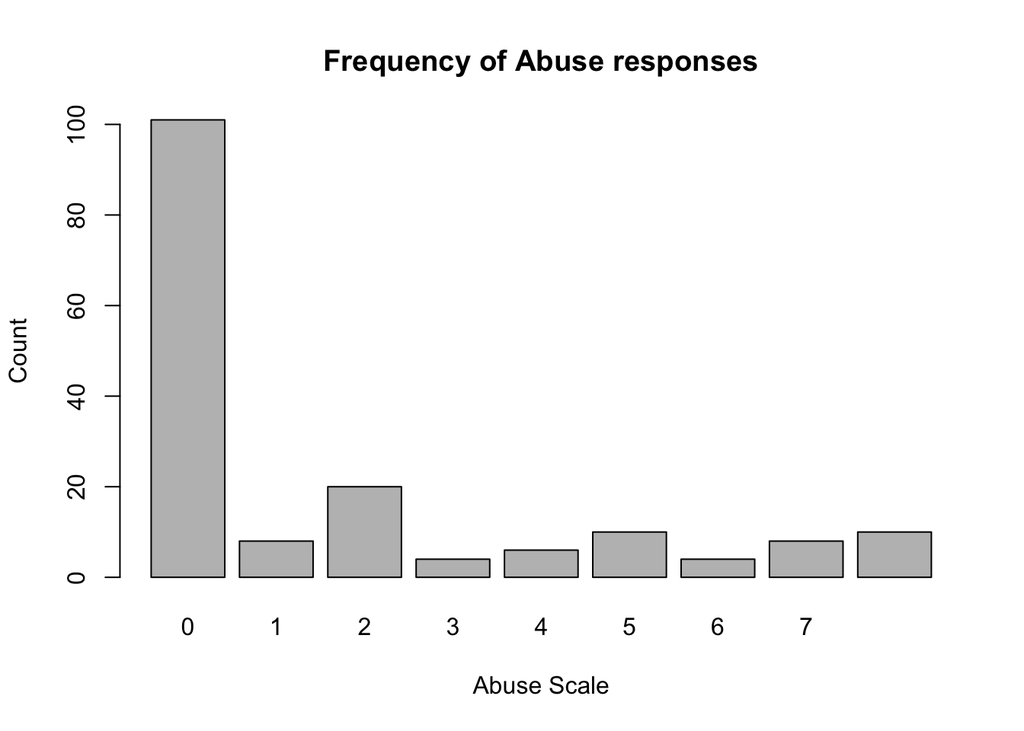

Moreover, the conditional distribution of survey response score `ADHD.Total` and `MD.TOTAL` seems unchanged for this subpopulation. So we make the imputation.

```
## [1] "Conditional Mean ADHD.Total: 34.9 Population Mean ADHD.Total: 34.5087719298246"
```

```
## [1] "Conditional Mean MD.Total: 10.6 Population Mean MD.TOTAL: 10.0760233918129"
```

### 1.3.2 Suicides

We choose to impute Suicide=0 for those observations where Suicide is not defined. The number of incidents is low, the most common response is 0 (No) and the conditional mean of ADHD.Total and MD.Total is unchanged for this subpopulation.

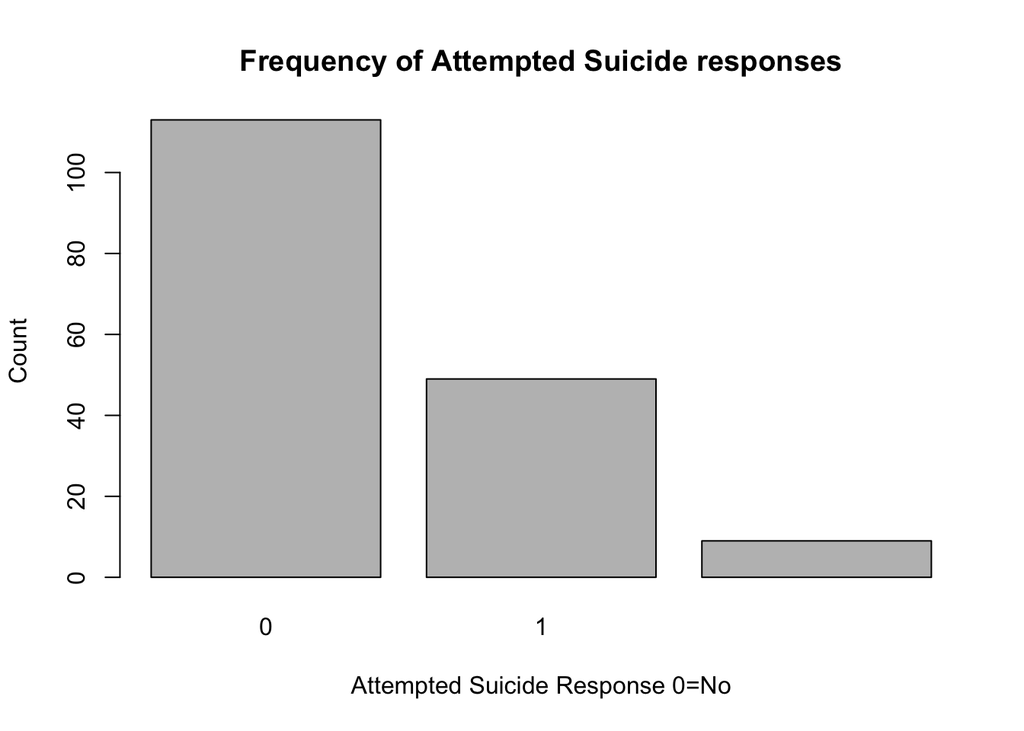

```
## [1] "Conditional Mean ADHD.Total: 36.5555555555556 Population Mean ADHD.Total: 34.5087719298246"
```

```
## [1] "Conditional Mean MD.Total: 10.3333333333333 Population Mean MD.TOTAL: 10.0760233918129"
```

### 1.3.3 History of Violence and Disorderly Conduct

Moreover, the conditional mean of `ADHD.Total` and `MD.TOTAL` is unaffected for this subpopulation.

| Disorderly Conduct | Disorderly Conduct 0 | Disorderly Conduct 1 | Disorderly Conduct NA |
| --- | --- | --- | --- |
| 0 | 45 | 79 | 0 |
| 1 | 0 | 40 | 0 |
| NA | 0 | 0 | 7 |

Note:  
Each row shows counts for History of Violence 0=No, 1=Yes

```
## [1] "Conditional Mean ADHD.Total: 35.4285714285714 Population Mean ADHD.Total: 34.5087719298246"
```

```
## [1] "Conditional Mean MD.Total: 10.4285714285714 Population Mean MD.TOTAL: 10.0760233918129"
```

## 1.4 Transforming Variables

In this section, we apply the above data imputation rules to the variables with missing values. Next, we construct factor equivalent variables with the naming convention of a `f` prefix to any abbreviated version of the original variable name. Lastly, we remove the older version of the columns with their factor equivalent.

A table below shows the translation from old to new variables along with the range of permitted values.

Note the following transformation from the original variable to the new one as follows:

Conversion of Old Variables to New

| OldVar | NewVar | Range |
| --- | --- | --- |
| Sex | fSex | M,F |
| Race | fRace | WH,AF,HI,AS,NA,OT |
| Court.order | fCO | Yes,No |
| Abuse | fAbuse | 0-7 (factor) |
| Hx.of.Violence | fHViol | Yes,No |
| Disorderly.Conduct | fDCond | Yes,No |
| Suicide | fSuic | Yes,No |
| Non.subst.Dx | fNonDx | 0,1,2 (factor) |
| Subst.Dx | fSubsDx | 0,1,2,3 (factor) |

## 1.5 Exporting the New Data Set

We export the dataset for reference purposes.

Data summary

| Name | ab |
| --- | --- |
| Number of rows | 171 |
| Number of columns | 52 |
| _______________________ |  |
| Column type frequency: |  |
| character | 6 |
| factor | 3 |
| numeric | 43 |
| ________________________ |  |
| Group variables | None |

**Variable type: character**

| skim_variable | n_missing | complete_rate | min | max | empty | n_unique | whitespace |
| --- | --- | --- | --- | --- | --- | --- | --- |
| fCO | 0 | 1 | 2 | 3 | 0 | 2 | 0 |
| fHViol | 0 | 1 | 2 | 3 | 0 | 2 | 0 |
| fDCond | 0 | 1 | 2 | 3 | 0 | 2 | 0 |
| fSuic | 0 | 1 | 2 | 3 | 0 | 2 | 0 |
| fSex | 0 | 1 | 1 | 1 | 0 | 2 | 0 |
| fRace | 0 | 1 | 2 | 2 | 0 | 4 | 0 |

**Variable type: factor**

| skim_variable | n_missing | complete_rate | ordered | n_unique | top_counts |
| --- | --- | --- | --- | --- | --- |
| fAbuse | 0 | 1 | TRUE | 8 | 0: 111, 2: 20, 5: 10, 1: 8 |
| fNonDx | 0 | 1 | FALSE | 3 | 0: 120, 1: 35, 2: 16 |
| fSubsDx | 0 | 1 | FALSE | 4 | 1: 61, 0: 42, 2: 35, 3: 33 |

**Variable type: numeric**

| skim_variable | n_missing | complete_rate | mean | sd | p0 | p25 | p50 | p75 | p100 | hist |
| --- | --- | --- | --- | --- | --- | --- | --- | --- | --- | --- |
| Age | 0 | 1 | 39.19 | 11.03 | 18 | 29.0 | 41 | 48.0 | 61 | ▅▅▅▇▃ |
| Education | 0 | 1 | 11.91 | 2.14 | 6 | 11.0 | 12 | 12.5 | 19 | ▁▅▇▂▁ |
| ADHD.Q1 | 0 | 1 | 1.70 | 1.30 | 0 | 1.0 | 2 | 3.0 | 4 | ▇▇▇▆▃ |
| ADHD.Q2 | 0 | 1 | 1.91 | 1.25 | 0 | 1.0 | 2 | 3.0 | 4 | ▅▇▇▆▃ |
| ADHD.Q3 | 0 | 1 | 1.92 | 1.27 | 0 | 1.0 | 2 | 3.0 | 4 | ▅▇▇▆▅ |
| ADHD.Q4 | 0 | 1 | 2.12 | 1.34 | 0 | 1.0 | 2 | 3.0 | 4 | ▅▅▇▅▆ |
| ADHD.Q5 | 0 | 1 | 2.26 | 1.45 | 0 | 1.0 | 3 | 3.0 | 5 | ▇▅▇▆▁ |
| ADHD.Q6 | 0 | 1 | 1.91 | 1.31 | 0 | 1.0 | 2 | 3.0 | 4 | ▆▅▇▇▃ |
| ADHD.Q7 | 0 | 1 | 1.84 | 1.19 | 0 | 1.0 | 2 | 3.0 | 4 | ▃▇▇▃▃ |
| ADHD.Q8 | 0 | 1 | 2.16 | 1.29 | 0 | 1.0 | 2 | 3.0 | 4 | ▃▇▇▇▆ |
| ADHD.Q9 | 0 | 1 | 1.92 | 1.32 | 0 | 1.0 | 2 | 3.0 | 4 | ▆▇▆▇▅ |
| ADHD.Q10 | 0 | 1 | 2.14 | 1.23 | 0 | 1.0 | 2 | 3.0 | 4 | ▂▇▇▅▅ |
| ADHD.Q11 | 0 | 1 | 2.29 | 1.24 | 0 | 1.0 | 2 | 3.0 | 4 | ▂▆▇▇▆ |
| ADHD.Q12 | 0 | 1 | 1.29 | 1.20 | 0 | 0.0 | 1 | 2.0 | 4 | ▇▇▆▂▂ |
| ADHD.Q13 | 0 | 1 | 2.37 | 1.24 | 0 | 1.5 | 2 | 3.0 | 4 | ▂▅▇▇▆ |
| ADHD.Q14 | 0 | 1 | 2.26 | 1.35 | 0 | 1.0 | 2 | 3.0 | 4 | ▅▅▆▇▆ |
| ADHD.Q15 | 0 | 1 | 1.64 | 1.40 | 0 | 0.0 | 1 | 3.0 | 4 | ▇▆▆▅▃ |
| ADHD.Q16 | 0 | 1 | 1.73 | 1.38 | 0 | 1.0 | 1 | 3.0 | 4 | ▆▇▆▃▅ |
| ADHD.Q17 | 0 | 1 | 1.53 | 1.29 | 0 | 0.0 | 1 | 2.0 | 4 | ▇▇▇▃▃ |
| ADHD.Q18 | 0 | 1 | 1.49 | 1.31 | 0 | 0.0 | 1 | 2.0 | 4 | ▇▇▆▃▃ |
| ADHD.Total | 0 | 1 | 34.51 | 16.72 | 0 | 21.0 | 34 | 48.0 | 72 | ▃▆▇▆▂ |
| MD.Q1a | 0 | 1 | 0.55 | 0.50 | 0 | 0.0 | 1 | 1.0 | 1 | ▆▁▁▁▇ |
| MD.Q1b | 0 | 1 | 0.57 | 0.50 | 0 | 0.0 | 1 | 1.0 | 1 | ▆▁▁▁▇ |
| MD.Q1c | 0 | 1 | 0.54 | 0.50 | 0 | 0.0 | 1 | 1.0 | 1 | ▇▁▁▁▇ |
| MD.Q1d | 0 | 1 | 0.58 | 0.50 | 0 | 0.0 | 1 | 1.0 | 1 | ▆▁▁▁▇ |
| MD.Q1e | 0 | 1 | 0.56 | 0.50 | 0 | 0.0 | 1 | 1.0 | 1 | ▆▁▁▁▇ |
| MD.Q1f | 0 | 1 | 0.70 | 0.46 | 0 | 0.0 | 1 | 1.0 | 1 | ▃▁▁▁▇ |
| MD.Q1g | 0 | 1 | 0.73 | 0.45 | 0 | 0.0 | 1 | 1.0 | 1 | ▃▁▁▁▇ |
| MD.Q1h | 0 | 1 | 0.57 | 0.50 | 0 | 0.0 | 1 | 1.0 | 1 | ▆▁▁▁▇ |
| MD.Q1i | 0 | 1 | 0.60 | 0.49 | 0 | 0.0 | 1 | 1.0 | 1 | ▆▁▁▁▇ |
| MD.Q1j | 0 | 1 | 0.39 | 0.49 | 0 | 0.0 | 0 | 1.0 | 1 | ▇▁▁▁▅ |
| MD.Q1k | 0 | 1 | 0.48 | 0.50 | 0 | 0.0 | 0 | 1.0 | 1 | ▇▁▁▁▇ |
| MD.Q1L | 0 | 1 | 0.58 | 0.49 | 0 | 0.0 | 1 | 1.0 | 1 | ▆▁▁▁▇ |
| MD.Q1m | 0 | 1 | 0.49 | 0.50 | 0 | 0.0 | 0 | 1.0 | 1 | ▇▁▁▁▇ |
| MD.Q2 | 0 | 1 | 0.73 | 0.44 | 0 | 0.0 | 1 | 1.0 | 1 | ▃▁▁▁▇ |
| MD.Q3 | 0 | 1 | 2.02 | 1.06 | 0 | 1.0 | 2 | 3.0 | 3 | ▂▃▁▅▇ |
| MD.TOTAL | 0 | 1 | 10.08 | 4.75 | 0 | 7.0 | 11 | 14.0 | 17 | ▃▃▆▇▇ |
| Alcohol | 0 | 1 | 1.35 | 1.39 | 0 | 0.0 | 1 | 3.0 | 3 | ▇▂▁▁▆ |
| THC | 0 | 1 | 0.81 | 1.27 | 0 | 0.0 | 0 | 1.5 | 3 | ▇▁▁▁▃ |
| Cocaine | 0 | 1 | 1.09 | 1.39 | 0 | 0.0 | 0 | 3.0 | 3 | ▇▁▁▁▅ |
| Stimulants | 0 | 1 | 0.12 | 0.53 | 0 | 0.0 | 0 | 0.0 | 3 | ▇▁▁▁▁ |
| Sedative.hypnotics | 0 | 1 | 0.12 | 0.54 | 0 | 0.0 | 0 | 0.0 | 3 | ▇▁▁▁▁ |
| Opioids | 0 | 1 | 0.39 | 0.99 | 0 | 0.0 | 0 | 0.0 | 3 | ▇▁▁▁▁ |

## 1.6 The Survey Is Not Representative of the US Population

Consequently, we should not apply statistics inferences and machine learning predictions from the dataset and our models to the general US population. The researcher needs to condition any inferences on the intended and true population.

### 1.6.1 Education

The Educational attainment of the survey population is below US average. US Census data shows US population 18 years and older have graduated high school or better is 89%. By comparison, in our sample only 68% have graduated high school or better. (We use the 18 years and older population to match the observed age range in the sample.) The below table shows the frequency of educational attainment by years of education within the survey population.

```
##
##  6  7  8  9 10 11 12 13 14 15 16 17 18 19
##  2  2  5 12 12 23 72 15 14  1  7  2  3  1
```

```
## [1] 0.6725146
```

[figure not shown]

[Source: U.S. Census Bureau]

### 1.6.2 Gender

Percentage by Gender

| F | M |
| --- | --- |
| 44.4 | 55.6 |

### 1.6.3 Race

The survey population is not representative of the racial composition of the US.

|  | AF | HI | OT | WH |
| --- | --- | --- | --- | --- |
| race_freq | 97.0 | 1.0 | 2.0 | 71.0 |
|  | 56.7 | 0.6 | 1.2 | 41.5 |

The US Census Bureau shows Whites are 76.3%, Blacks are 13.4%, Hispanics are 18.5%, Asians are 5.9%, American Indian are 1.3% according to 2019 data available on [this link](https://www.census.gov/quickfacts/fact/table/US/PST045219).

# 2 Multiple Factor Analysis - A Generalization of PCA

Multiple Factor analysis is a generalization of PCA that allows the combined use of quantitative variables and qualitative variables in a single analysis. Its aim is similar to that of principal components analysis. But whereas PCA does not allow qualitative variables, MFA allow them by combining two techniques: PCA for quantitative variables and Multiple Correspondence Analysis (MCA) for qualitiative variables. The key contribution of MFA is to systematically group variables as: `active` or `supplementary` and to assign a weight to the contribution of each group of variables to the final output. The key authors of the textbook explaining the MFA approach and the software package `FactoMineR` and `FactoShiny` are French: Jerome Pages and Francois Husson, “Multiple Factor Analysis by Example Using R” and the [FactoMineR website](http://factominer.free.fr/) contains the required software.

```
##  [1] "fSex"               "fRace"              "Age"
##  [4] "Education"          "Alcohol"            "THC"
##  [7] "Cocaine"            "Stimulants"         "Sedative.hypnotics"
## [10] "Opioids"            "fCO"                "fHViol"
## [13] "fDCond"             "fSuic"              "fNonDx"
## [16] "fSubsDx"            "fAbuse"             "ADHD.Total"
## [19] "MD.Q3"              "MD.TOTAL"
```

## 2.1 FactoMineR MFA Analysis

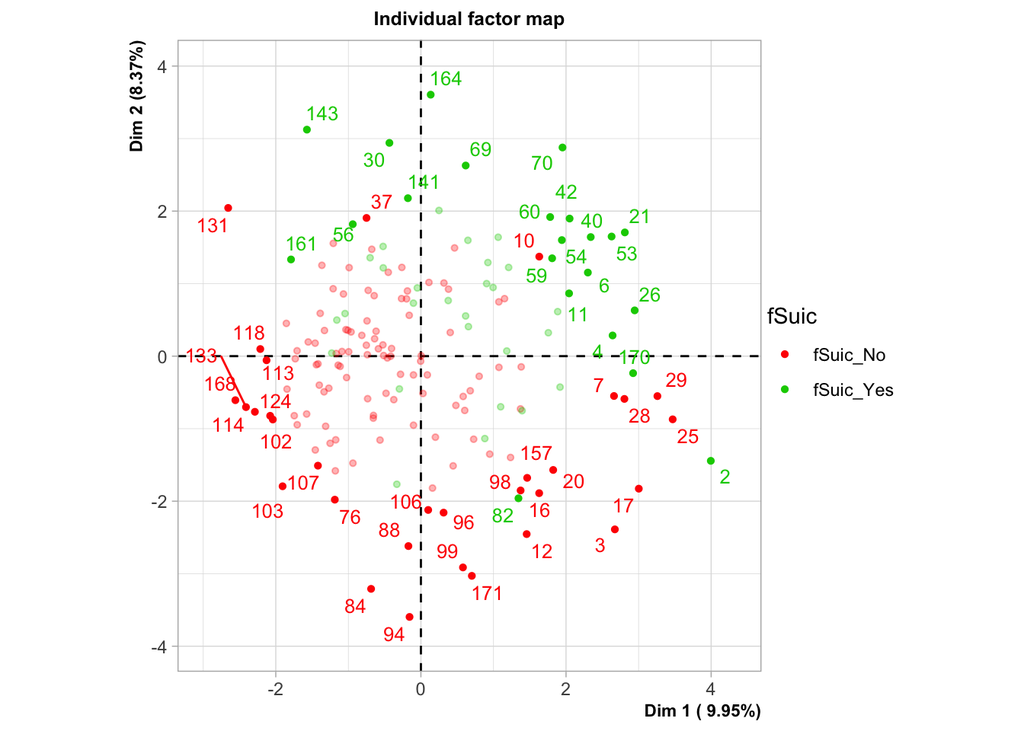

The above plot overlays Suicide on the individual observations in the MFA plot of first and second MFA dimensions. These two axes have the highest explanatory power of the data variance. It shows that the majority of Suicide = Yes reports occurs in the upper right hand quadrant. This means the MFA axes do a good job of separating the Suicide and non-Suicide patients using an MFA analysis.

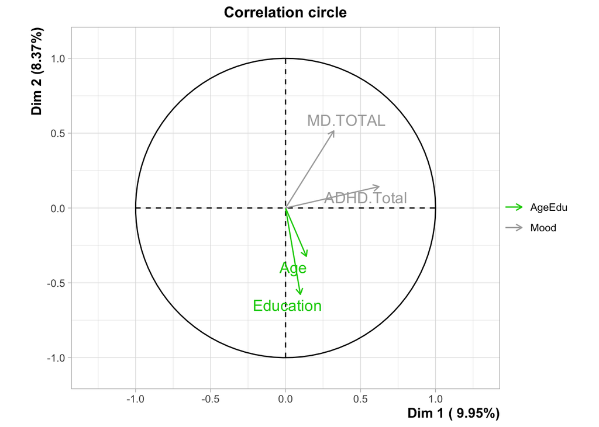

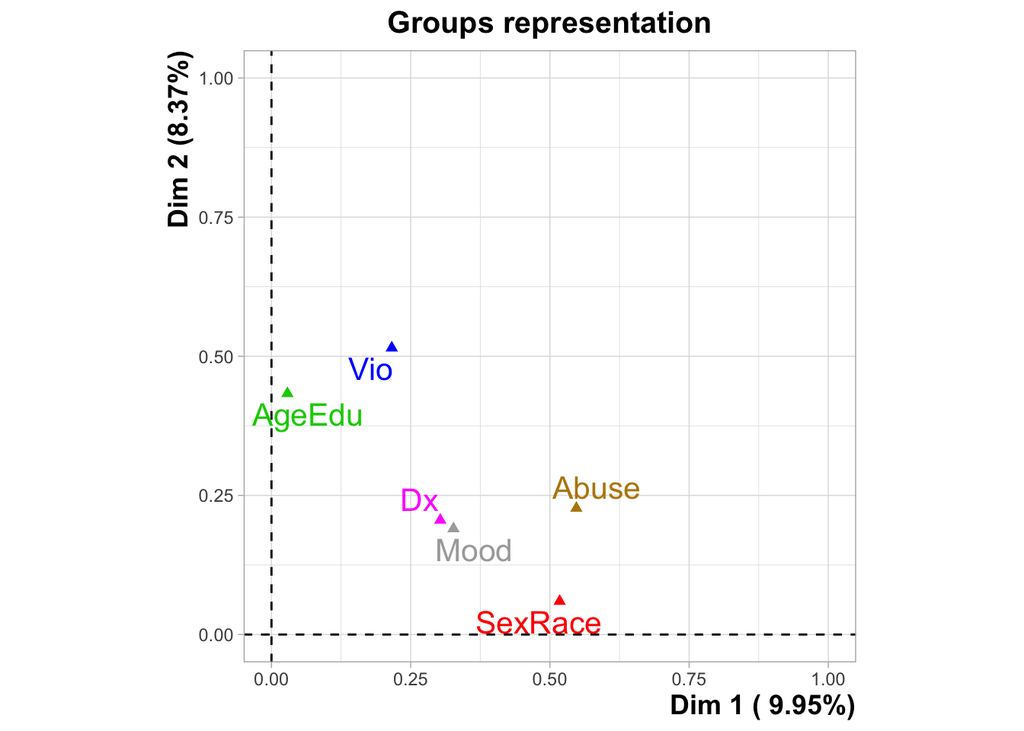

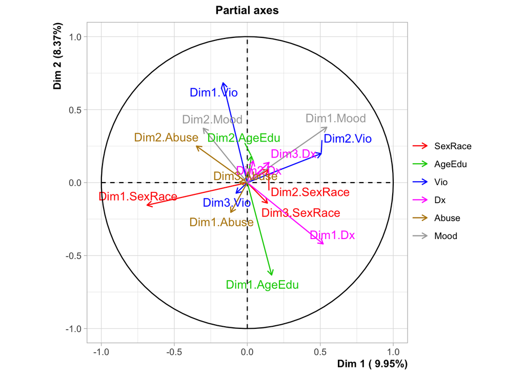

## MFA

```
##  [1] "Age"                "Education"          "fAbuse"
##  [4] "fCO"                "fHViol"             "fDCond"
##  [7] "fSuic"              "fNonDx"             "fSubsDx"
## [10] "ADHD.Q1"            "ADHD.Q2"            "ADHD.Q3"
## [13] "ADHD.Q4"            "ADHD.Q5"            "ADHD.Q6"
## [16] "ADHD.Q7"            "ADHD.Q8"            "ADHD.Q9"
## [19] "ADHD.Q10"           "ADHD.Q11"           "ADHD.Q12"
## [22] "ADHD.Q13"           "ADHD.Q14"           "ADHD.Q15"
## [25] "ADHD.Q16"           "ADHD.Q17"           "ADHD.Q18"
## [28] "MD.Q1a"             "MD.Q1b"             "MD.Q1c"
## [31] "MD.Q1d"             "MD.Q1e"             "MD.Q1f"
## [34] "MD.Q1g"             "MD.Q1h"             "MD.Q1i"
## [37] "MD.Q1j"             "MD.Q1k"             "MD.Q1L"
## [40] "MD.Q1m"             "MD.Q2"              "MD.Q3"
## [43] "Alcohol"            "THC"                "Cocaine"
## [46] "Stimulants"         "Sedative.hypnotics" "Opioids"
## [49] "fSex"               "fRace"
```

# 3 Appendices

## 3.1 References

Abdi, Hervé, and Lynne J. Williams. 2010. “Principal Component Analysis.” John Wiley and Sons, Inc. WIREs Comp Stat 2: 433–59 (http://staff.ustc.edu.cn/~zwp/teach/MVA/abdi-awPCA2010.pdf)

[MFA - Multiple Factor Analysis] (http://www.sthda.com/english/articles/31-principal-component-methods-in-r-practical-guide/116-mfa-multiple-factor-analysis-in-r-essentials)

Multiple Factor Analysis Playlist for using FactoMineR (https://www.youtube.com/playlist?list=PLnZgp6epRBbRX8TEp1HlFGqfMf_AxYEj7)